# Data Cleaning

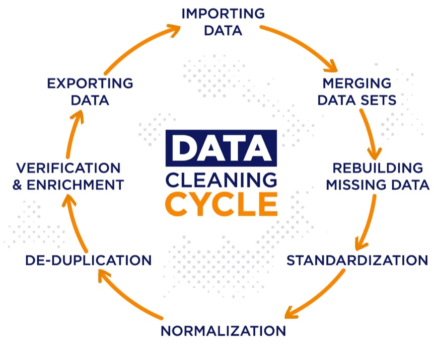

## [## REKT Database (Python)](https://github.com/anly501/anly-501-project-TegveerG/blob/main/codes/Data_Cleaning/REKT_Database_Cleaning.ipynb)

[**Raw Data (first 5 rows)**](https://github.com/anly501/anly-501-project-TegveerG/tree/main/data/Raw%20Data/Python_REKT_Database_API)

|  | id | project_name | description | name_categories | token_name | proof_archive_link | technical_issue | token_address | logo_link | date | proof_link | website_link | webarchive_link | twitter_link | telegram_link | our_post_link | funds_lost | funds_returned | active | git_hub | git_hub_contract_link | discord | bug_bounty_program_link | bug_bounty_program_company | audit_code_conf | is_verified_source_code | is_public_team | scam_type | network | … |
| --- | --- | --- | --- | --- | --- | --- | --- | --- | --- | --- | --- | --- | --- | --- | --- | --- | --- | --- | --- | --- | --- | --- | --- | --- | --- | --- | --- | --- | --- | --- |
| 0 | 3058 | Terra Classic | <p><strong>Quick Summary</strong></p><p>A complex mixture of events and market dynamics cost the implosion of the $40b Terra (Classic) Network.&nbsp;</p><p><br></p><p><strong>Details of the Exploit</s… | Stablecoin | LUNC, USTC | https://twitter.com/OnChainWizard/status/1524123935570382851, https://rekt.news/ru/luna-rekt/, https://mobile.twitter.com/hasufl/status/1523817151471230976 | None | 0x7e43d25EaD96B1058f671F6690ea705BA2C7e5B9, 0xa47c8bf37f92abed4a126bda807a7b7498661acd | safe/files/scamDatabase/logo/62b31ccc0d07e.jpeg | 2022-5-8 | https://www.nansen.ai/research/on-chain-forensics-demystifying-terrausd-de-peg?utm_source=twitter&utm_medium=organic&utm_campaign=Research_USTdepeg_27May22, https://www.cnet.com/personal-finance/crypt… | https://www.terra.money/ | None | https://twitter.com/terra_money | https://t.me/TerraNetworkLobby | None | 40000000000 | None | 1 | https://github.com/terra-money/ | None | https://twitter.com/terra_money | None | None | 0.0 | 0.0 | 1.0 | {‘type’: ‘Bank Run’} | {} | … |
| 1 | 2762 | Africrypt | <p><strong>Quick Summary</strong></p><p>Ameer and Raees Cajee, the exchange’s founders, were reported missing in June 2021 after alleging that almost $3.6 billion invested in the protocol was stolen i… | CeFi | None | None | None | None | safe/files/scamDatabase/logo/61e049352a11a.png | 2021-6-23 | https://finance.yahoo.com/news/africrypt-bitcoin-disappearance-174636634.html, https://www.bloomberg.com/news/articles/2021-06-23/s-african-brothers-vanish-and-so-does-3-6-billion-in-bitcoin | https://africrypt.io/ | https://web.archive.org/web/20200921145240/https://africrypt.io/ | None | None | None | 3600000000 | None | 1 | None | None | None | None | None | NaN | 0.0 | 1.0 | {‘type’: ‘Exit Scam’} | {} | … |
| 2 | 2878 | PlusToken | <p><strong>Quick Summary</strong></p><p>The perpetrators of one of the largest digital currency frauds have been sentenced to up to 11 years in prison. In addition, the PlusToken operators were penali… | CeFi | None | None | None | None | safe/files/scamDatabase/logo/62432b9d39213.png | 2019-12-16 | https://cointelegraph.com/news/vanuatu-extradicts-six-chinese-citizens-allegedly-involved-in-crypto-scheme, https://www.nasdaq.com/articles/ringleaders-of-plustoken-scam-jailed-for-up-to-11-years-2020… | https://thecryptonizer.team-plt.com/ | https://web.archive.org/web/20220125033211/https://www.coindesk.com/policy/2020/12/01/ringleaders-of-plustoken-scam-jailed-for-up-to-11-years/ | None | None | None | 2900000000 | None | 1 | None | None | None | None | None | NaN | 0.0 | 0.0 | {‘type’: ‘Exit Scam’} | {} | … |
| 3 | 2861 | Thodex | <p><strong>Quick Summary</strong></p><p>Thodex a turkish crypto exchange went down with other $2 billion of user funds entangled in massive fraud and mismanagement.<strong><br></strong></p><p><br></p>… | CeFi | None | None | None | None | safe/files/scamDatabase/logo/6241c6cb5dadc.jpeg | 2021-4-22 | https://www.cnbc.com/2021/04/23/bitcoin-btc-ceo-of-turkish-cryptocurrency-exchange-thodex-missing.html, https://www.dw.com/en/turkish-cryptocurrency-platform-founder-vanishes-fraud-suspected/a-5730295… | https://www.thodex.com/ | https://web.archive.org/web/20220405133149/https://coingeek.com/missing-thodex-ceo-may-face-40000-years-behind-bars-in-new-indictment/ | https://twitter.com/thodexofficial | None | None | 2000000000 | None | 1 | None | None | None | None | None | NaN | 0.0 | 0.0 | {‘type’: ‘Exit Scam’} | {} | … |
| 4 | 2735 | BitConnect | <p><strong>Quick Summary</strong></p><p>BitConnect was a Ponzi Scheme that managed to raise approx. $2 billion dollars from investors before it collapsed.</p><p><strong><br>Details of the Exploit</str… | Borrowing and Lending,CeFi | BCC | None | None | None | safe/files/scamDatabase/logo/61bb58e866760.jpeg | 2018-1-15 | None | https://www.bitconnect.co/ | https://web.archive.org/web/20220426131429/https://economictimes.indiatimes.com/tech/technology/bitconnects-satish-kumbhani-charged-by-us-in-2-4-billion-ponzi-scam/articleshow/89844151.cms, https://we… | None | None | None | 2000000000 | 56000000 | 1 | None | None | None | None | None | NaN | 0.0 | 0.0 | {‘type’: ‘Exit Scam’} | {} | … |

After loading the record data and getting a quick view of it, we can move to cleaning/pre-processing the data. I first started with stripping off the whitespaces off the column names. Then, I went on to dropping variables that would not assist in our analysis. Most of the variables that we shall drop from our 31 columns are links to external sites, such as web archive, discord, and github. Moreover, these variables contain more than 2900 NaN values out of a total observation count of 3055. However, the variable proof_link could be important if I decide to scrape text data from the linked article about a crypto attack. We shall also get rid of the technical_issue field because it only contains 4 non-NaN values and, more importantly, does not have any insightful use. Therefore, I find it sensible to entirely remove these fields, instead of getting rid of their existing NaN values, for EDA and modeling purposes.

Next, we proceed to variable identification and typecasting, an important step to recognize what types of data our variables fit in. For variables identified as Integer type, the summary is as follows:

- `id` variable is a unique, nominal code indicating the token/coin associated with the crypto attack. Converting it to category type would not be beneficial due to the large number of unique tokens present in the database. **This variable should be converted to object/string type**.
- `active` variable most probably represents whether the crypto project is currently active in the market. I perused the API documentation to try to find this response variable’s significance, but could not. Moreover, it has only taken on one as a value for ALL observations. This would mean that all crypto projects present in the database are still active. We could keep this variable for now, but **converting it to category would be better as it most likely would take on two values, either 1 (active) or 0 (inactive).**

For variables identified as Float type, the summary is as follows:

- The `is_verified_source_code` and `is_public_team` variables take on the values of either 0 or 1. Hence, we convert them to category type.

*Extracting important time-based features for better EDA experience:*

The features from extracted are `month_of_attack`, `day_of_week_of_attack`, and `day_of_year_of_attack` from the raw date variable.

### Removing HTML Tags from Description variable

HOWEVER, a crucial step was missing, which was that of getting rid of all the NaN’s present in the `description` variable. This variable itself has 285 missing values, but when we add the `funds_lost` variable in the mix, the total missing values is only 284. The `funds_lost`variable is a highly valuable attribute and, possibly, a target variable for modeling. We cannot get rid of even that single observation that has a `funds_lost` value but no description. Therefore, seen in the two screenshots below, we could not get rid of ALL NaN’s present in the `funds_lost` variable and `description` variable.

[figure not shown]

The 284 rows were the only ones discarded while cleaning the dataset. Yes, there are missing values present in other rows, but we have done well to eliminate most, if not all, unnecessary data for EDA!

After all these above steps were completed, we come up with a cleaned data like this:

|  | id | project_name | description | name_categories | token_name | token_address | date | proof_link | webarchive_link | funds_lost | funds_returned | active | is_verified_source_code | is_public_team | scam_type | network | scamNetworks | auditedBy | month_of_attack | day_of_week_of_attack | day_of_year_of_attack |
| --- | --- | --- | --- | --- | --- | --- | --- | --- | --- | --- | --- | --- | --- | --- | --- | --- | --- | --- | --- | --- | --- |
| 0 | 3058 | Terra Classic | <p><strong>Quick Summary</strong></p><p>A complex mixture of events and market dynamics cost the implosion of the $40b Terra (Classic) Network.&nbsp;</p><p><br></p><p><strong>Details of the Exploit</s… | Stablecoin | LUNC, USTC | 0x7e43d25EaD96B1058f671F6690ea705BA2C7e5B9, 0xa47c8bf37f92abed4a126bda807a7b7498661acd | 2022-05-08 | https://www.nansen.ai/research/on-chain-forensics-demystifying-terrausd-de-peg?utm_source=twitter&utm_medium=organic&utm_campaign=Research_USTdepeg_27May22, https://www.cnet.com/personal-finance/crypt… | None | 4.000000e+10 | NaN | 1 | 0.0 | 1.0 | {‘type’: ‘Bank Run’} | {} | [{‘networks_id’: 1003, ‘scam_database_id’: 3058, ‘networks’: {‘id’: 1003, ‘name’: ‘Terra Classic’, ‘icon_link’: ‘safe/files/network/terra-classic.png’}}] | [{‘audit_link’: ‘safe/files/audit/pdf/CertiK_Audit_for_Terra_v18.pdf’, ‘date’: ‘2020-09-03T00:00:00.000Z’, ‘partner’: {‘id’: 8, ‘name’: ‘Certik’, ‘logo_link’: ‘safe/files/partner/logo/609520cbb1bba.pn… | 5.0 | 6.0 | 128.0 |
| 1 | 2762 | Africrypt | <p><strong>Quick Summary</strong></p><p>Ameer and Raees Cajee, the exchange’s founders, were reported missing in June 2021 after alleging that almost $3.6 billion invested in the protocol was stolen i… | CeFi | None | None | 2021-06-23 | https://finance.yahoo.com/news/africrypt-bitcoin-disappearance-174636634.html, https://www.bloomberg.com/news/articles/2021-06-23/s-african-brothers-vanish-and-so-does-3-6-billion-in-bitcoin | https://web.archive.org/web/20200921145240/https://africrypt.io/ | 3.600000e+09 | NaN | 1 | 0.0 | 1.0 | {‘type’: ‘Exit Scam’} | {} | [{‘networks_id’: 1666600003, ‘scam_database_id’: 2762, ‘networks’: {‘id’: 1666600003, ‘name’: ‘CEX’, ‘icon_link’: ‘safe/files/network/cex.png’}}] | [] | 6.0 | 2.0 | 174.0 |
| 2 | 2878 | PlusToken | <p><strong>Quick Summary</strong></p><p>The perpetrators of one of the largest digital currency frauds have been sentenced to up to 11 years in prison. In addition, the PlusToken operators were penali… | CeFi | None | None | 2019-12-16 | https://cointelegraph.com/news/vanuatu-extradicts-six-chinese-citizens-allegedly-involved-in-crypto-scheme, https://www.nasdaq.com/articles/ringleaders-of-plustoken-scam-jailed-for-up-to-11-years-2020… | https://web.archive.org/web/20220125033211/https://www.coindesk.com/policy/2020/12/01/ringleaders-of-plustoken-scam-jailed-for-up-to-11-years/ | 2.900000e+09 | NaN | 1 | 0.0 | 0.0 | {‘type’: ‘Exit Scam’} | {} | [{‘networks_id’: 1666600003, ‘scam_database_id’: 2878, ‘networks’: {‘id’: 1666600003, ‘name’: ‘CEX’, ‘icon_link’: ‘safe/files/network/cex.png’}}] | [] | 12.0 | 0.0 | 350.0 |
| 3 | 2861 | Thodex | <p><strong>Quick Summary</strong></p><p>Thodex a turkish crypto exchange went down with other $2 billion of user funds entangled in massive fraud and mismanagement.<strong><br></strong></p><p><br></p>… | CeFi | None | None | 2021-04-22 | https://www.cnbc.com/2021/04/23/bitcoin-btc-ceo-of-turkish-cryptocurrency-exchange-thodex-missing.html, https://www.dw.com/en/turkish-cryptocurrency-platform-founder-vanishes-fraud-suspected/a-5730295… | https://web.archive.org/web/20220405133149/https://coingeek.com/missing-thodex-ceo-may-face-40000-years-behind-bars-in-new-indictment/ | 2.000000e+09 | NaN | 1 | 0.0 | 0.0 | {‘type’: ‘Exit Scam’} | {} | [{‘networks_id’: 1666600003, ‘scam_database_id’: 2861, ‘networks’: {‘id’: 1666600003, ‘name’: ‘CEX’, ‘icon_link’: ‘safe/files/network/cex.png’}}] | [] | 4.0 | 3.0 | 112.0 |
| 4 | 2735 | BitConnect | <p><strong>Quick Summary</strong></p><p>BitConnect was a Ponzi Scheme that managed to raise approx. $2 billion dollars from investors before it collapsed.</p><p><strong><br>Details of the Exploit</str… | Borrowing and Lending,CeFi | BCC | None | 2018-01-15 | None | https://web.archive.org/web/20220426131429/https://economictimes.indiatimes.com/tech/technology/bitconnects-satish-kumbhani-charged-by-us-in-2-4-billion-ponzi-scam/articleshow/89844151.cms, https://we… | 2.000000e+09 | 56000000.0 | 1 | 0.0 | 0.0 | {‘type’: ‘Exit Scam’} | {} | [{‘networks_id’: 1666600003, ‘scam_database_id’: 2735, ‘networks’: {‘id’: 1666600003, ‘name’: ‘CEX’, ‘icon_link’: ‘safe/files/network/cex.png’}}] | [] | 1.0 | 0.0 | 15.0 |
| 5 | 2871 | WoToken | <p><strong style=‘box-sizing: inherit; margin: 0px; padding: 0px; border: 0px; outline: none; -webkit-tap-highlight-color: rgba(0, 0, 0, 0); transition: background 0.45s ease-in 0s, background-color 0… | CeFi | None | None | 2020-05-14 | https://cointelegraph.com/news/plustoken-scammer-implicated-in-chinas-second-ten-figure-crypto-ponzi, https://www.theblockcrypto.com/linked/82783/china-crypto-ponzi-prison-wotoken-billions, https://ne… | https://web.archive.org/web/20181029073006/http://wotoken.pro/ | 1.000000e+09 | NaN | 1 | 0.0 | 0.0 | {‘type’: ‘Exit Scam’} | {} | [{‘networks_id’: 1666600003, ‘scam_database_id’: 2871, ‘networks’: {‘id’: 1666600003, ‘name’: ‘CEX’, ‘icon_link’: ‘safe/files/network/cex.png’}}] | [] | 5.0 | 3.0 | 135.0 |
| 6 | 2879 | Ronin | <p><strong>Quick Summary</strong></p><p>The Ronin bridge has been exploited for 173,600 Ethereum and 25.5M USDC.</p><p><br></p><p><strong>Details of the Exploit &nbsp;</strong></p><p>The Ronin Network… | Bridge | RON | 0xe514d9deb7966c8be0ca922de8a064264ea6bcd4 | 2022-03-29 | https://twitter.com/Ronin_Network/status/1508828719711879168, https://roninblockchain.substack.com/p/community-alert-ronin-validators?s=w | None | 6.250000e+08 | 155800000.0 | 1 | 0.0 | 0.0 | {‘type’: ‘Exploit’} | {} | [{‘networks_id’: 1666600009, ‘scam_database_id’: 2879, ‘networks’: {‘id’: 1666600009, ‘name’: ‘Ronin’, ‘icon_link’: ‘safe/files/network/ronin.png’}}] | [] | 3.0 | 1.0 | 88.0 |
| 7 | 2543 | Poly Network | <p><strong>Quick Summary</strong></p><p><span style=‘color: rgb(65, 65, 65); font-family: “Open Sans”, sans-serif; font-size: 14px; font-style: normal; font-variant-ligatures: normal; font-variant-cap… | Other | None | None | 2021-08-10 | None | None | 6.021896e+08 | 602189570.0 | 1 | 0.0 | 0.0 | {‘type’: ‘Exploit’} | {} | [{‘networks_id’: 1, ‘scam_database_id’: 2543, ‘networks’: {‘id’: 1, ‘name’: ‘Ethereum’, ‘icon_link’: ‘safe/files/network/ethereum.png’}}] | [] | 8.0 | 1.0 | 222.0 |
| 8 | 2643 | Coincheck | <p><strong>Quick Summary</strong></p><p>On Jan. 26, about 523 million NEM (XEM) tokens, valued over $530 million at the time, were illicitly transferred from its hot wallet address, resulting in an an… | CeFi | None | None | 2018-01-26 | https://www.reuters.com/article/us-japan-cryptocurrency-q-a/the-coincheck-hack-and-the-issue-with-crypto-assets-on-centralized-exchanges-idUSKBN1FI0K4, https://fortune.com/2018/01/31/coincheck-hack-ho… | None | 5.340000e+08 | 534000000.0 | 1 | 0.0 | 0.0 | {‘type’: ‘Exploit’} | {} | [{‘networks_id’: 1666600003, ‘scam_database_id’: 2643, ‘networks’: {‘id’: 1666600003, ‘name’: ‘CEX’, ‘icon_link’: ‘safe/files/network/cex.png’}}] | [] | 1.0 | 4.0 | 26.0 |
| 9 | 2808 | Mt. Gox (3) | <p><strong>Quick Summary</strong></p><p>One of the world’s largest exchanges, Mt. Gox, declared bankruptcy in 2014 after being hacked, while losing most of its assets. At the time of bankruptcy, the e… | CeFi | None | None | 2014-02-24 | https://www.coindesk.com/markets/2014/02/25/mt-gox-allegedly-loses-350-million-in-bitcoin-744400-btc-rumoured-to-be-insolvent/, https://www.reuters.com/investigates/special-report/bitcoin-gox/ | None | 4.730000e+08 | NaN | 1 | 0.0 | 0.0 | {‘type’: ‘Exploit’} | {} | [{‘networks_id’: 1666600003, ‘scam_database_id’: 2808, ‘networks’: {‘id’: 1666600003, ‘name’: ‘CEX’, ‘icon_link’: ‘safe/files/network/cex.png’}}] | [] | 2.0 | 0.0 | 55.0 |

Clean data with missing values pertaining to the description variable.

## [## News Text (R)](https://github.com/anly501/anly-501-project-TegveerG/blob/main/codes/Data_Cleaning/NEWSAPI_cleaning.Rmd)